# Civics

5/8/2020

```r
library(tidyverse)
library(mosaic)
library(car)
library(readxl)
library(pander)
```

```r
civics <- read_excel("Civic Data.xlsx")
View(civics)
```

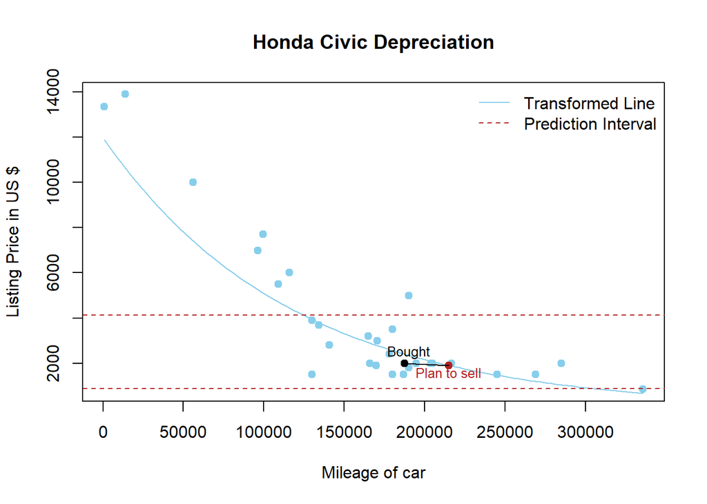

```r
plot(Price ~ Mileage, data = civics, pch = 19, col = "skyblue", xlab = "Mileage of car", ylab = "Listing Price in US $", main = "Honda Civic Depreciation")
civics.lm <- lm(Price ~ Mileage, data = civics)

x0 <- 187658
y0 <- 2000
x1 <- 215000
y1 <- 1903.344

c.log.lm <- lm(log(Price) ~ Mileage, data = civics)
b <- coef(c.log.lm)
curve(exp(b[1] + b[2]*x), add = TRUE, lty = 1, col = "skyblue")
points(x = 187658, y = 2000, col = "black", pch = 19)
points(x = 215000, y = 1903.344, col = "firebrick", pch = 19)
segments(x0, y0, x1 = x0, y1 = y0, lty = 1)
legend("topright", legend = c("Transformed Line", "Prediction Interval"), col = c("skyblue","firebrick"), bty = "n", lty = c(1,2))
text(190000, 2500, "Bought", col = "black", cex = .8)
text(215000, 1600, "Plan to sell", col = "firebrick", cex = 0.8)
segments(x0 = 187658, y0 = 2000, x1 = 215000, y1 = 1903.344)
abline(h=4120, col = "firebrick", lty = 2)
abline(h=879.2, col = "firebrick", lty = 2)
```

## Introduction & Data

```r
(1903.344-2000)/(215000-187658)
```

```
## [1] -0.003535074
```

Which can be interpreted as every mile I drive, my car depreciates at an average value of 0.354 cents. That is a bit difficult to visualize, so if we multiply it by the number of miles from my current home near Boise, Idaho, to the Ricks building on BYUI campus, which is 323 miles according to [Google Maps](https://www.google.com/maps) following the route of I-84, I lose about 1.14 dollars in value.

The red dashed lines are the upper and lower bound of the prediction interval, which was calculated using the transformed regression model. The actual calculations are showed later in this analysis.

It is important to note that the prices recorded are the **list** prices, and not necessarily the cost to a buyer. The selection process was not completely unbiased, because I was determined to find cars with mileage ranging from 0-200,000. Though, as you can see, even with that bias, the majority of the cars I selected range from having 100,000-200,000 miles. The process of choosing a transformation method for this data is explained later.

The Matematical model for this regression is:

$$Y_i'= log(Y_i) = \beta_0+\beta_1X_i+\epsilon_i \text{ where } \epsilon_i \sim N(0,\sigma^2)$$

Which could also be written as:

$$Y_i= e^{\beta_0+\beta_1X_i+\epsilon_i} \text{ where } \epsilon_i \sim N(0,\sigma^2)$$

## Hypotheses

$$H_O: \beta_1 = 0$$

$$H_a: \beta_1 \neq0$$
The significance level for this test will be set at:
$$\alpha = 0.05$$

For purposes of this analysis, we are only concerned for the value of $\beta_1$, because the interpretation of $\beta_0$ would be the average price of a Honda Civic with 0 miles, and even disregarding the fact that an individual can never purchase a vehicle with exactly 0 miles on it due to the testing of each vehicle, it is not worth predicting, because it is a known value for a given trim of Honda Civic.

## Analysis

The results of the regression test are as follows, which will be interpreted in the conclusion:

```r
summary(c.log.lm) %>% pander(caption = "Transformed test results")
```

|  | Estimate | Std. Error | t value | Pr(>\|t\|) |
| --- | --- | --- | --- | --- |
| **(Intercept)** | 9.391 | 0.1705 | 55.08 | 6.677e-31 |
| **Mileage** | -8.554e-06 | 9.487e-07 | -9.017 | 6.534e-10 |

Transformed test results

| Observations | Residual Std. Error | $R^2$ | Adjusted $R^2$ |
| --- | --- | --- | --- |
| 31 | 0.3688 | 0.7371 | 0.728 |

The prediction interval shown in the first graph has been included for the predicted selling price of my vehicle:

```r
exp(predict(c.log.lm, data.frame(Mileage=215000), interval = "prediction")) %>% pander()
```

| fit | lwr | upr |
| --- | --- | --- |
| 1903 | 879.2 | 4120 |

A simple linear regression was initally ran on the test and an abline was plotted. This is depicted by the solid line. Unsatisfied with the approximation, I attempted a transformation of:
$$\hat{Y_i}'= \frac{1}{\hat{Y_i}}=b_0+b_1X_i$$
Which is depicted on the plot as the dashed line, along with it’s asymptote. I then decided to do a log transformation, which is shown and modeled above, and decided that was the most accurate transformation for this data. I reached this conclusion in large part to due to the interpretation of the asymptote, being that it would not allow any car to have less than approximately 10,000 miles. The asymptote also causes the line to become very steep at about 50,000 miles, and would predict a cost of $273,377 for a Honda Civic with 15,000 miles on it.

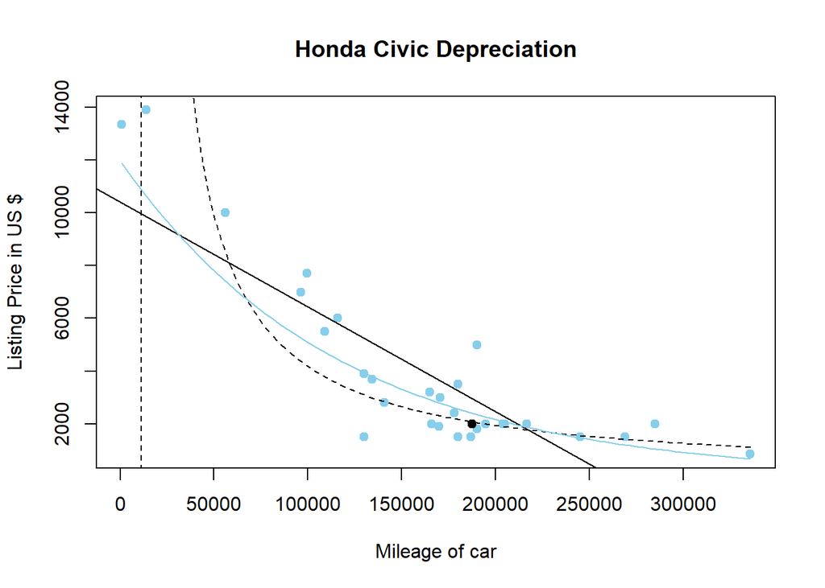

```r
plot(Price ~ Mileage, data = civics, pch = 19, col = "skyblue", xlab = "Mileage of car", ylab = "Listing Price in US $", main = "Honda Civic Depreciation")
civics.lm <- lm(Price ~ Mileage, data = civics)
abline(civics.lm)

c.1ov.lm <- lm(1/(Price) ~ Mileage, data = civics)
b <- coef(c.1ov.lm)
curve(1/(b[1] + b[2]*x), add = TRUE, lty = 2)

b <- coef(c.log.lm)
curve(exp(b[1] + b[2]*x), add = TRUE, lty = 1, col = "skyblue")

points(x = 187658, y = 2000, col = "black", pch = 19)
```

A boxCox plot was also constructed, showing that the logarithmic transformation is recommended as nearly an optimal choice for this data.

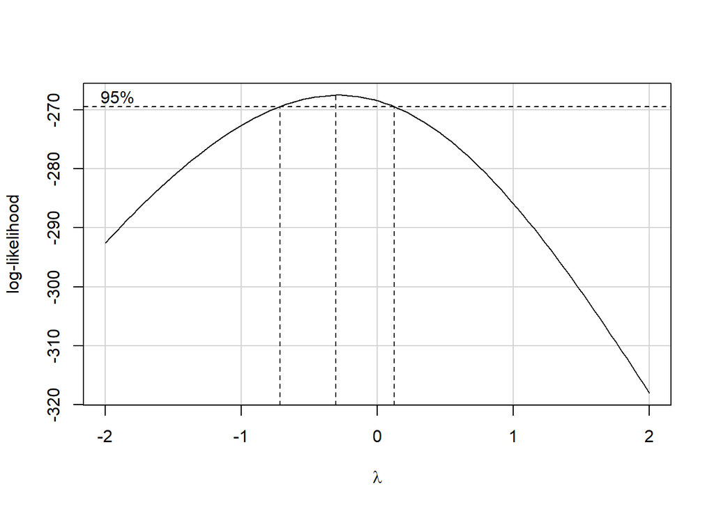

```r
boxCox(civics.lm)
```

### Diagnostic Plots

```r
par(mfrow=c(1,3))
plot(c.log.lm,which=1)
qqPlot(c.log.lm$residuals)
```

```
## [1] 20  8
```

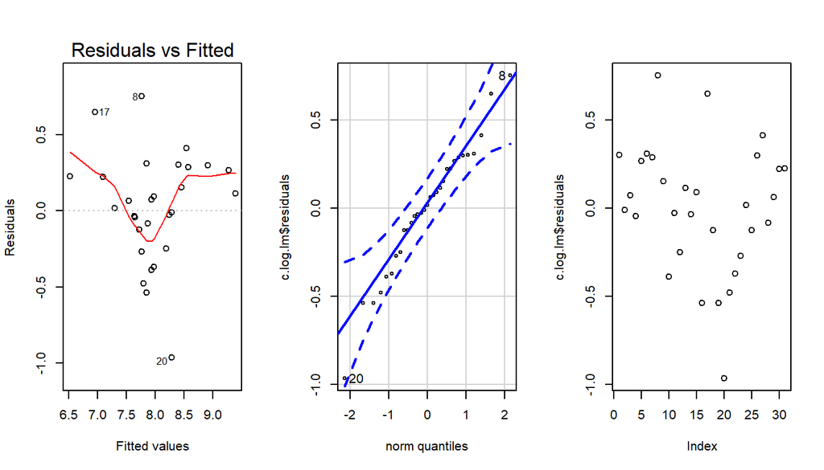

```r
plot(c.log.lm$residuals)
```

We have a clear issue in the residuals vs fitted plot with both linearity and constant variance. This is possibly due to the fact that I did not control for the year of the car, as a 2009 civic with 180,000 miles on it will typically be listed for more than a 2001 honda civic with the same amount of miles. Our normality plot seems to check out however, showing us that our residuals are normally distributed. The thrid plot raises a bit of concern with a somewhat apparent “U-shape”, creating concern about the independence of the residuals.

## Conclusion

Given our p-value for our slope term, $p < .0000000006534 <\alpha = 0.05$, it is safe to say that $\beta_1\neq0$, by rejecting our null hypothesis. Our value of $b_1$ can be interpreted to mean that for every 10,000 miles driven, a Honda Civic increases by a factor of `exp(10000*b[2])`= 0.918, or in other words, it loses 8.2% of it’s value for every 10,000 miles driven.

Our value of $R^2$ is also considered, and was calculated to be $0.7371$. This means that 73.71% of the variability in $Y$ is explained by our regression line.

Unfortunately, when our diagnostic plots are considered, we cannot fully trust the results of our test.